# 03 · sPLS regression on muscle growth

## Load packages

```r
pacman::p_load(here, mixOmics, dplyr, tidyr, purrr, ggplot2, patchwork, readr, writexl)
here::i_am("07_Multivariate/03_spls/a_script/03_spls.qmd")
```

## Read proteins and phenotype

Growth is each leg’s change in vastus lateralis (VL) and rectus femoris (RF) cross-sectional area (CSA) and echo intensity; the blood-adjusted abundances keep the blood index out of the panels.

```r
stage <- here("07_Multivariate", "03_spls")
proteins <- readRDS(here("01_Preprocess", "02_Quantification", "c_data", "proteins_adjusted.rds"))
phenotype <- read_csv(here("00_Input", "phenotype.csv"), show_col_types = FALSE)
gene_of <- set_names(proteins$genes$Genes, rownames(proteins))
```

## Changes per leg

Changes are taken as in `03_Protein_Association`, so the two analyses ask the same question.

```r
outcomes <- c(
  vl_csa = "VL CSA change (cm²)", rf_csa = "RF CSA change (cm²)",
  vl_echo = "VL echo change (a.u.)", rf_echo = "RF echo change (a.u.)"
)
legs <- proteins$targets |>
  mutate(leg_id = paste(participant, leg, sep = "_")) |>
  select(leg_id, participant, leg, treatment, timepoint, sample_id) |>
  pivot_wider(names_from = timepoint, values_from = sample_id) |>
  drop_na(T1, T2) |>
  left_join(select(phenotype, -treatment), by = c("participant", "leg"),
    relationship = "one-to-one") |>
  mutate(
    vl_csa = vl_csa_post_cm2 - vl_csa_pre_cm2,
    rf_csa = rf_csa_post_cm2 - rf_csa_pre_cm2,
    vl_echo = vl_echo_post_au - vl_echo_pre_au,
    rf_echo = rf_echo_post_au - rf_echo_pre_au
  )
change <- t(proteins$E[, legs$T2] - proteins$E[, legs$T1])
rownames(change) <- legs$leg_id
count(legs, treatment)
```

```
# A tibble: 2 × 2
  treatment     n
  <chr>     <int>
1 BFR          32
2 HLRT         33
```

## Fits

sPLS1 asks whether a few proteins’ changes together predict growth. Single-arm fits have one leg per participant, so folds are folds of people; the pooled fit doubles the legs, and because a person’s two legs grow together (r = 0.57 for VL CSA) `perf()` holds both out at once. `tune.spls()` cannot do that, so the pooled panel size may lean optimistic.

```r
fits_to_run <- expand_grid(outcome = names(outcomes), fit = c("BFR", "HLRT", "pooled")) |>
  mutate(rows = map(fit, function(f) {
    if (f == "pooled") seq_len(nrow(legs)) else which(legs$treatment == f)
  }))
fits_to_run |> mutate(n_legs = lengths(rows)) |> select(-rows)
```

```
# A tibble: 12 × 3
   outcome fit    n_legs
   <chr>   <chr>   <int>
 1 vl_csa  BFR        32
 2 vl_csa  HLRT       33
 3 vl_csa  pooled     65
 4 rf_csa  BFR        32
 5 rf_csa  HLRT       33
 6 rf_csa  pooled     65
 7 vl_echo BFR        32
 8 vl_echo HLRT       33
 9 vl_echo pooled     65
10 rf_echo BFR        32
11 rf_echo HLRT       33
12 rf_echo pooled     65
```

## Tune, fit and cross-validate

Q² judges each fit: above 0.0975 a component predicts better than chance by the package’s rule, and below 0 worse than the mean. Panel size is tuned on the same data and there is no permutation reference, so the errors lean optimistic.

```r
keep_grid <- c(5, 10, 20, 50, 100, 200, 500, 1000)
fit_spls <- function(outcome, fit, rows) {
  x <- change[rows, ]
  y <- legs[[outcome]][rows]
  tuned <- tune.spls(x, y, ncomp = 2, test.keepX = keep_grid, validation = "Mfold", folds = 5,
    nrepeat = 50, measure = "MAE", seed = 2026)
  model <- spls(x, y, ncomp = 2, keepX = tuned$choice.keepX)
  performance <- if (fit == "pooled") {
    perf(model, validation = "Mfold", folds = split(seq_along(rows), legs$participant[rows]))
  } else {
    perf(model, validation = "Mfold", folds = 5, nrepeat = 50, seed = 2026)
  }
  list(tuned = tuned, model = model, performance = performance)
}
fits <- mutate(fits_to_run, result = pmap(list(outcome, fit, rows), fit_spls))
```

## Prediction error

MSEP and Q² are relative to the outcome’s variance, so a fit that predicts no better than the mean reads as MSEP 1 and Q² 0.

```r
measure <- function(performance, name) performance$measures[[name]]$summary$mean
model_summary <- pmap(fits, function(outcome, fit, rows, result) {
  tibble(
    outcome = outcome, fit = fit, n_legs = length(rows), component = 1:2,
    keep_x = unname(result$tuned$choice.keepX),
    tune_mae = map2_dbl(keep_x, component,
      \(k, h) result$tuned$error.rate[as.character(k), h]),
    msep = measure(result$performance, "MSEP"),
    rmsep = measure(result$performance, "RMSEP"),
    r2 = measure(result$performance, "R2"),
    q2 = measure(result$performance, "Q2"),
    q2_total = measure(result$performance, "Q2.total")
  )
}) |>
  list_rbind()
model_summary |> mutate(across(where(is.double), \(x) signif(x, 3)))
```

```
# A tibble: 24 × 11
   outcome fit    n_legs component keep_x tune_mae  msep rmsep      r2        q2
   <chr>   <chr>   <int>     <int>  <dbl>    <dbl> <dbl> <dbl>   <dbl>     <dbl>
 1 vl_csa  BFR        32         1     20    0.379 1.28  1.13  0.0309  -0.325
 2 vl_csa  BFR        32         2      5    0.395 1.42  1.19  0.0365  -4.49
 3 vl_csa  HLRT       33         1   1000    0.305 0.969 0.984 0.057    0.000596
 4 vl_csa  HLRT       33         2   1000    0.324 1.11  1.05  0.0279  -1.74
 5 vl_csa  pooled     65         1    500    0.331 1.1   1.05  0.00697 -0.12
 6 vl_csa  pooled     65         2      5    0.334 1.1   1.05  0.00142 -1.33
 7 rf_csa  BFR        32         1     50    0.719 1.21  1.1   0.0204  -0.251
 8 rf_csa  BFR        32         2   1000    0.741 1.3   1.14  0.0541  -4.86
 9 rf_csa  HLRT       33         1   1000    0.781 1.24  1.11  0.0127  -0.282
10 rf_csa  HLRT       33         2   1000    0.74  1.24  1.11  0.032   -4.5
# ℹ 14 more rows
# ℹ 1 more variable: q2_total <dbl>
```

## Panels

Stability across the refits separates a reproducible panel from one fitted to noise.

```r
panels <- pmap(fits, function(outcome, fit, rows, result) {
  map(1:2, function(h) {
    loading <- result$model$loadings$X[, h]
    stable <- result$performance$features$stability.X[[h]]
    tibble(protein = names(loading), loading = unname(loading)) |>
      filter(loading != 0) |>
      mutate(
        outcome = outcome, fit = fit, component = h, gene = gene_of[protein],
        stability = unname(stable[protein]), .before = protein
      ) |>
      arrange(desc(abs(loading)))
  }) |>
    list_rbind()
}) |>
  list_rbind()
panels |> summarise(proteins = n(), stable_80 = sum(stability >= 0.8),
  .by = c(outcome, fit, component))
```

```
# A tibble: 24 × 5
   outcome fit    component proteins stable_80
   <chr>   <chr>      <int>    <int>     <int>
 1 vl_csa  BFR            1       20         3
 2 vl_csa  BFR            2        5         0
 3 vl_csa  HLRT           1     1000       501
 4 vl_csa  HLRT           2     1000       319
 5 vl_csa  pooled         1      500       420
 6 vl_csa  pooled         2        5         1
 7 rf_csa  BFR            1       50         7
 8 rf_csa  BFR            2     1000       171
 9 rf_csa  HLRT           1     1000       420
10 rf_csa  HLRT           2     1000       111
# ℹ 14 more rows
```

## Held-out predictions

`perf()` does not return its predictions, so one cross-validation pass on the same fold scheme supplies the figure’s held-out values.

```r
set.seed(2026)
held_out <- pmap(fits, function(outcome, fit, rows, result) {
  x <- change[rows, ]
  y <- legs[[outcome]][rows]
  keep_x <- result$tuned$choice.keepX[[1]]
  folds <- if (fit == "pooled") {
    split(seq_along(rows), legs$participant[rows])
  } else {
    split(sample(seq_along(rows)), rep(1:5, length.out = length(rows)))
  }
  predicted <- numeric(length(rows))
  for (test in folds) {
    model <- spls(x[-test, ], y[-test], ncomp = 1, keepX = keep_x)
    predicted[test] <- predict(model, x[test, , drop = FALSE])$predict[, 1, 1]
  }
  tibble(outcome = outcome, fit = fit, leg_id = legs$leg_id[rows],
    treatment = legs$treatment[rows], observed = y, predicted = predicted)
}) |>
  list_rbind()
held_out |> summarise(r = cor(observed, predicted), .by = c(outcome, fit))
```

```
# A tibble: 12 × 3
   outcome fit           r
   <chr>   <chr>     <dbl>
 1 vl_csa  BFR     0.0904
 2 vl_csa  HLRT    0.267
 3 vl_csa  pooled  0.0835
 4 rf_csa  BFR    -0.00739
 5 rf_csa  HLRT    0.0798
 6 rf_csa  pooled  0.228
 7 vl_echo BFR    -0.279
 8 vl_echo HLRT    0.442
 9 vl_echo pooled -0.0290
10 rf_echo BFR    -0.459
11 rf_echo HLRT    0.218
12 rf_echo pooled  0.0478
```

## Figures

One page per outcome, so the three fits of an outcome read side by side.

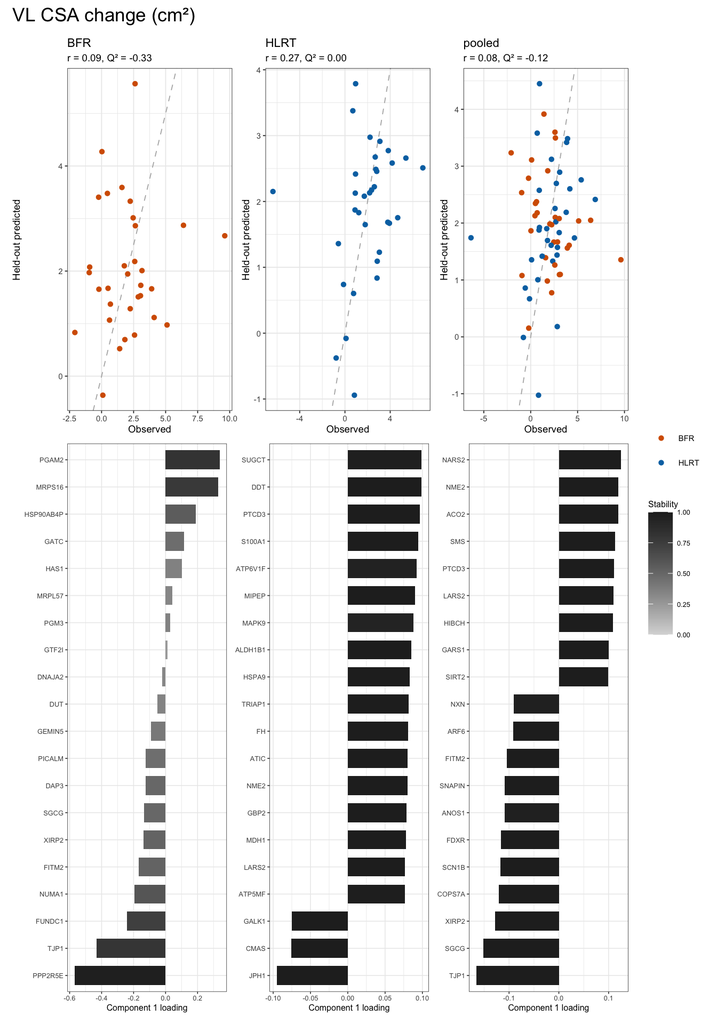

```r
arm_colours <- c(BFR = "#D55E00", HLRT = "#0072B2")

prediction_plot <- function(this_outcome, this_fit) {
  rows <- filter(held_out, outcome == this_outcome, fit == this_fit)
  q2 <- filter(model_summary, outcome == this_outcome, fit == this_fit, component == 1)$q2
  ggplot(rows, aes(observed, predicted, colour = treatment)) +
    geom_abline(linetype = "dashed", colour = "grey70") +
    geom_point(size = 1.4, show.legend = TRUE) +
    scale_colour_manual(values = arm_colours, limits = names(arm_colours)) +
    labs(
      title = this_fit, x = "Observed", y = "Held-out predicted", colour = NULL,
      subtitle = sprintf("r = %.2f, Q² = %.2f", cor(rows$observed, rows$predicted), q2)
    ) +
    theme_bw(base_size = 7)
}

loading_plot <- function(this_outcome, this_fit) {
  panels |>
    filter(outcome == this_outcome, fit == this_fit, component == 1) |>
    slice_max(abs(loading), n = 20, with_ties = FALSE) |>
    ggplot(aes(loading, reorder(gene, loading), fill = stability)) +
    geom_col(width = 0.7) +
    scale_fill_gradient(low = "grey85", high = "grey15", limits = c(0, 1)) +
    labs(x = "Component 1 loading", y = NULL, fill = "Stability") +
    theme_bw(base_size = 6)
}

pages <- map(names(outcomes), function(name) {
  fit_names <- c("BFR", "HLRT", "pooled")
  wrap_plots(map(fit_names, \(f) prediction_plot(name, f)), nrow = 1) /
    wrap_plots(map(fit_names, \(f) loading_plot(name, f)), nrow = 1) +
    plot_layout(heights = c(1, 1.6), guides = "collect") +
    plot_annotation(title = outcomes[[name]])
})
pages[[1]]
```

```r
pdf(file.path(stage, "b_reports", "03_spls.pdf"), width = 8.27, height = 11.69)
walk(pages, print)
invisible(dev.off())
```

## Save results

```r
write_xlsx(
  list(models = model_summary, panels = panels, predictions = held_out),
  file.path(stage, "c_data", "03_spls.xlsx")
)
```